# Homework 5

Blarry Wang

1/22/2020

### Loading the Data & Libraries

```r
library(gapminder)
library(ggplot2)
library(dplyr)
library(grid)
library(gridExtra)
data(gapminder)
```

### Analysis

#### Model 1: GDP Per Capital v. Life Expectancy

```r
model <- lm(lifeExp ~ gdpPercap, data = gapminder)
outOfSample = c(min(gapminder$gdpPercap),
            mean(gapminder$gdpPercap),
            median(gapminder$gdpPercap),
            max(gapminder$gdpPercap))
pred_df <- expand.grid(gdpPercap = outOfSample)
pred <- predict(model, newdata = pred_df, interval = "confidence", level = 0.95)
```

The linear model predicted with 95% confidence that when is shown in the table below:

```
##         fit       lwr       upr
## 1  54.14002  53.52933  54.75072
## 2  59.47444  58.97595  59.97292
## 3  56.65701  56.12484  57.18918
## 4 140.78744 135.38688 146.18799
```

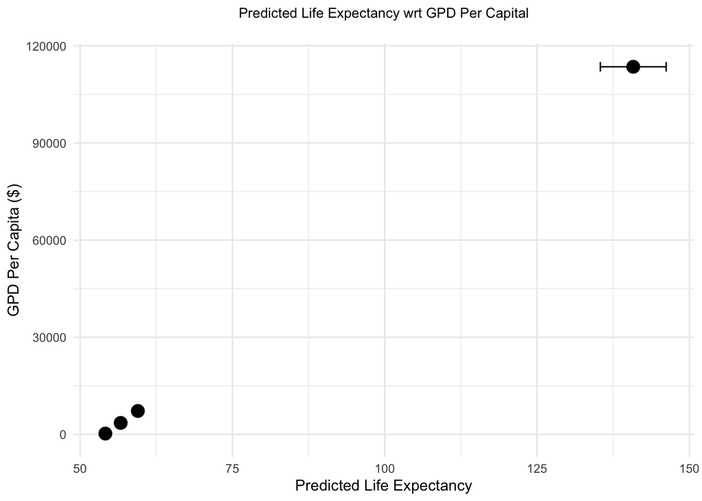

```r
plot1 <- ggplot(bind_cols(pred_df, as.data.frame(pred)),
                aes(y = outOfSample, x = fit, xmin = lwr, xmax = upr)) +
                geom_point(size = 4.0) +
                geom_errorbarh() +
                labs(y = "GPD Per Capita ($)",
                     x = "Predicted Life Expectancy",
                     title = "Predicted Life Expectancy wrt GPD Per Capital\n") +
                theme_minimal() +
                theme(plot.title = element_text(size = 10, hjust = 0.5))
plot1
```

As we can see from the graph, when the GPD per capita is $120,000, the life expectancy is more than double of that of the lower GDP per capita counties. But the fact that the predicted age is above 125 highlights that the life expectancy doesn’t fit well by a linear model.

#### Model 2: GDP Per Capital v. Life Expectancy Controlling Population

Now let’s control for population in the model.

```r
model <- lm(lifeExp ~ gdpPercap + pop, data = gapminder)
pred_df <- expand.grid(gdpPercap = outOfSample, pop = mean(gapminder$pop))
pred <- predict(model, newdata = pred_df, interval = "confidence", level = 0.95)
```

The dimension of the scenarios is 4, 2.

The linear model predicted with 95% confidence that when is shown in the table below:

```
##         fit       lwr       upr
## 1  54.12132  53.51335  54.72929
## 2  59.47444  58.97823  59.97065
## 3  56.64713  56.11737  57.17689
## 4 141.07255 135.69490 146.45020
```

If we plot the fitted values, we can see that controlling for population did not make a significant impact on the model.

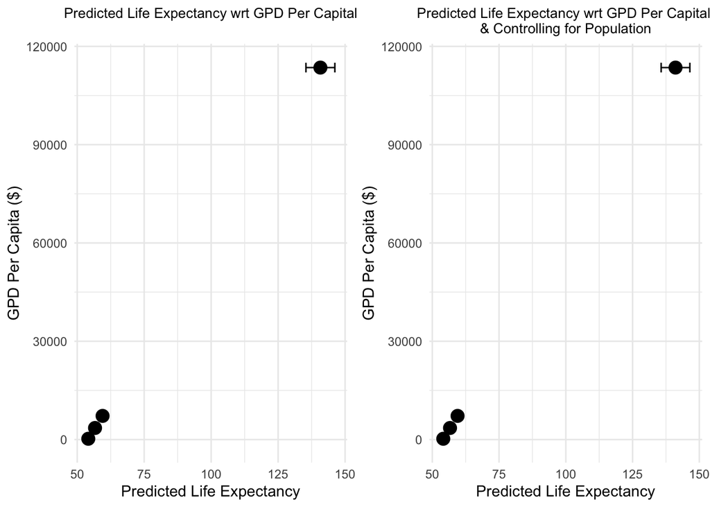

```r
plot2 <- ggplot(bind_cols(pred_df, as.data.frame(pred)),
                aes(y = outOfSample, x = fit, xmin = lwr, xmax = upr)) +
                geom_point(size = 4.0) +
                geom_errorbarh() +
                labs(y = "GPD Per Capita ($)",
                     x = "Predicted Life Expectancy",
                     title = "Predicted Life Expectancy wrt GPD Per Capital \n& Controlling for Population") +
                theme_minimal() +
                theme(plot.title = element_text(size = 10, hjust = 0.5))


grid.arrange(plot1, plot2, nrow = 1)
```

#### Model 3: Population v. Controlling for GDP Per Capital

We will build a slightly different model.

```r
model <- lm(lifeExp ~ pop + gdpPercap, data = gapminder %>% filter(year == 1977))
gdpPercap_pred <- (gapminder %>% filter(year == 1977 & country %in% c("Afghanistan", "Canada", "Japan", "Mexico", "Nepal")))$gdpPercap
populations_pred <- c(max(gapminder$pop), min(gapminder$pop))
pred_df <- expand.grid(pop = populations_pred, gdpPercap = gdpPercap_pred)
pred <- predict(model, newdata = pred_df, interval = "confidence", level = 0.95)
```

The linear model predicted with 95% confidence that when is shown in the table below:

```
##         fit      lwr       upr
## 1  65.59948 46.07215  85.12682
## 2  53.85442 51.93211  55.77674
## 3  83.45315 63.57993 103.32637
## 4  71.70809 68.71288  74.70330
## 5  78.86042 59.14368  98.57716
## 6  67.11536 64.89619  69.33453
## 7  71.37240 51.81111  90.93368
## 8  59.62734 58.10363  61.15105
## 9  65.52239 45.99499  85.04978
## 10 53.77733 51.84508  55.70957
```

If we plot the fitted values, we can see that in 1977, while contries with larger population tend to have a greater life expectancy, their variance is also a lot larger. There is no meaningful relation we can tell from the graph.

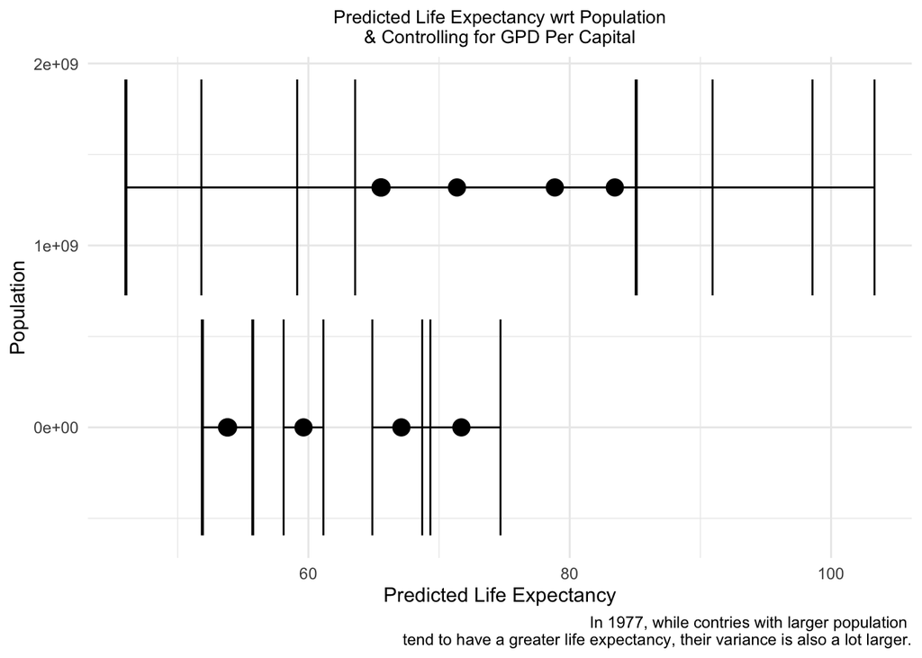

```r
plot3 <- ggplot(bind_cols(pred_df, as.data.frame(pred)),
                aes(y = pred_df$pop, x = fit, xmin = lwr, xmax = upr)) +
                geom_point(size = 4.0) +
                geom_errorbarh() +
                labs(y = "Population",
                     x = "Predicted Life Expectancy",
                     title = "Predicted Life Expectancy wrt Population\n& Controlling for GPD Per Capital",
                     caption = "In 1977, while contries with larger population
                     tend to have a greater life expectancy, their variance is also a lot larger.") +
                theme_minimal() +
                theme(plot.title = element_text(size = 10, hjust = 0.5))
plot3
```